# Estimating Exam Scores: Supervised Learning

Timmy Miller, MPS Candidate

October 24, 2022

# Introduction

Hi there! My name is Timmy and in this document I will be giving a walk-through on how to run basic supervised machine learning techniques on a dataset. The purpose of this document is to act as a guide to someone looking to run a supervised machine learning prediction on multiple variables.

## Dataset

[Link to Data](https://www.kaggle.com/datasets/whenamancodes/students-performance-in-exams) This dataset tracks the grades for 1000 students on 3 different tests: math, reading, and writing. The dataset also includes other categorical variables, including things like ethnicity and gender.

## Creating Dummy Variables

Using the `glimpse()` code from `dplyr`, we can obtain the structure of the exam dataset.

```
## Rows: 1,000
## Columns: 8
## $ gender           <chr> "male", "female", "male", "male", "male", "female", "…
## $ race_ethnicity   <chr> "group A", "group D", "group E", "group B", "group E"…
## $ parent_edu       <chr> "high school", "some high school", "some college", "h…
## $ lunch            <chr> "standard", "free/reduced", "free/reduced", "standard…
## $ test_prep_course <chr> "completed", "none", "none", "none", "completed", "no…
## $ math_score       <dbl> 67, 40, 59, 77, 78, 63, 62, 93, 63, 47, 99, 80, 77, 7…
## $ read_score       <dbl> 67, 59, 60, 78, 73, 77, 59, 88, 56, 42, 83, 87, 87, 7…
## $ write_score      <dbl> 63, 55, 50, 68, 68, 76, 63, 84, 65, 45, 85, 90, 85, 7…
```

We can see that we have three numerical variables, `math_score`, `read_score`, and `write_score`. However, the rest of the variables are character or categorical values. It will be important to transform this categorical variables into “Dummy Variables”, which means replacing each category with a numerical value. The code I used to create these dummy variables for each category is shown below.

- **Gender**
  - Male = 1, Female = 0
- **Race/Ethnicity**
  - groupA = 1, groupB = 2, groupC = 3, groupD = 4, groupE = 5
- **Parent Level of Education**
  - some high school = 1, high school = 2, some college = 3, associate’s degree = 4, bachelor’s degree = 5, master’s degree = 6
- **Lunch**
  - standard = 1, reduced/free = 0

### Gender

```r
exams_clean <- exams
exams_clean$gender <- ifelse(exams_clean$gender == "male", 1, 0)
```

### Race/Ethnicity

```r
exams_clean$race_ethnicity <- ifelse(exams_clean$race_ethnicity == "group A", 1, exams_clean$race_ethnicity)
exams_clean$race_ethnicity <- ifelse(exams_clean$race_ethnicity == "group B", 2, exams_clean$race_ethnicity)
exams_clean$race_ethnicity <- ifelse(exams_clean$race_ethnicity == "group C", 3, exams_clean$race_ethnicity)
exams_clean$race_ethnicity <- ifelse(exams_clean$race_ethnicity == "group D", 4, exams_clean$race_ethnicity)
exams_clean$race_ethnicity <- ifelse(exams_clean$race_ethnicity == "group E", 5, exams_clean$race_ethnicity)

exams_clean$race_ethnicity <- as.numeric(exams_clean$race_ethnicity)
```

### Parental Level of Education

```r
exams_clean$parent_edu <- ifelse(exams_clean$parent_edu == "some high school", 1, exams_clean$parent_edu)
exams_clean$parent_edu <- ifelse(exams_clean$parent_edu == "high school", 2, exams_clean$parent_edu)
exams_clean$parent_edu <- ifelse(exams_clean$parent_edu == "some college", 3, exams_clean$parent_edu)
exams_clean$parent_edu <- ifelse(exams_clean$parent_edu == "associate\'s degree", 4, exams_clean$parent_edu)
exams_clean$parent_edu <- ifelse(exams_clean$parent_edu == "bachelor\'s degree", 5, exams_clean$parent_edu)
exams_clean$parent_edu <- ifelse(exams_clean$parent_edu == "master\'s degree", 6, exams_clean$parent_edu)

exams_clean$parent_edu <- as.numeric(exams_clean$parent_edu)
```

### Lunch

```r
exams_clean$lunch <- ifelse(exams_clean$lunch == "standard", 1, 0)
exams_clean$lunch <- as.numeric(exams_clean$lunch)
```

### Test Prep Course

```r
exams_clean$test_prep_course <- ifelse(exams_clean$test_prep_course == "completed", 1, 0)
exams_clean$test_prep_course <- as.numeric(exams_clean$test_prep_course)
```

## Linear Model: Cumulative Exam Score Predictions

We can quickly look at the `structure()` of our `exams_clean` dataset and see our new numerical dummy variables.

```r
str(exams_clean)
```

```
## spec_tbl_df [1,000 × 8] (S3: spec_tbl_df/tbl_df/tbl/data.frame)
##  $ gender          : num [1:1000] 1 0 1 1 1 0 0 1 1 1 ...
##  $ race_ethnicity  : num [1:1000] 1 4 5 2 5 4 1 5 4 3 ...
##  $ parent_edu      : num [1:1000] 2 1 3 2 4 2 5 3 2 3 ...
##  $ lunch           : num [1:1000] 1 0 0 1 1 1 1 1 1 0 ...
##  $ test_prep_course: num [1:1000] 1 0 0 0 1 0 0 1 0 0 ...
##  $ math_score      : num [1:1000] 67 40 59 77 78 63 62 93 63 47 ...
##  $ read_score      : num [1:1000] 67 59 60 78 73 77 59 88 56 42 ...
##  $ write_score     : num [1:1000] 63 55 50 68 68 76 63 84 65 45 ...
##  - attr(*, "spec")=
##   .. cols(
##   ..   gender = col_character(),
##   ..   `race/ethnicity` = col_character(),
##   ..   `parental level of education` = col_character(),
##   ..   lunch = col_character(),
##   ..   `test preparation course` = col_character(),
##   ..   `math score` = col_double(),
##   ..   `reading score` = col_double(),
##   ..   `writing score` = col_double()
##   .. )
##  - attr(*, "problems")=<externalptr>
```

```r
df1 <- exams_clean %>%
    mutate(
        cum_score = math_score + read_score + write_score
    )
df1 <- df1[-c(6:8)] # Removes individual scores
```

```r
test <- df1[250:350,]
train <- df1[-c(250:350),]
```

Now, we can call the `lm()` function to create a linear regression with cumulative score as the response variable and all other variables as the independent variables. In the same chunk, we will also run the `summary()` function to get a good look at our new model.

```r
lm1 <- lm(cum_score ~ ., data = train)
summary(lm1)
```

```
##
## Call:
## lm(formula = cum_score ~ ., data = train)
##
## Residuals:
##      Min       1Q   Median       3Q      Max
## -112.829  -25.130    0.927   27.612   87.419
##
## Coefficients:
##                  Estimate Std. Error t value Pr(>|t|)
## (Intercept)      130.0876     5.0859  25.578  < 2e-16 ***
## gender            -7.1504     2.4891  -2.873  0.00417 **
## race_ethnicity     8.0240     1.0968   7.316  5.7e-13 ***
## parent_edu         7.8898     0.8251   9.562  < 2e-16 ***
## lunch             30.5793     2.6059  11.735  < 2e-16 ***
## test_prep_course  21.6074     2.6180   8.253  5.5e-16 ***
## ---
## Signif. codes:  0 '***' 0.001 '**' 0.01 '*' 0.05 '.' 0.1 ' ' 1
##
## Residual standard error: 37.17 on 893 degrees of freedom
## Multiple R-squared:  0.2871, Adjusted R-squared:  0.2831
## F-statistic: 71.93 on 5 and 893 DF,  p-value: < 2.2e-16
```

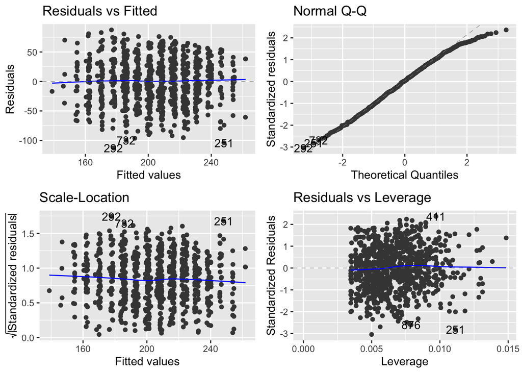

Autoplot of lm1

```r
autoplot(lm1)
```